# RESULTS for ‘same data different analysts’ project, ‘Many EcoEvo Analysts’ dataset

Luke J. Eberhart-Phillips and Martin Bulla

2020-08-08 14:20:07

## Chick Mortality Model

### mortality~net+sex-ratio

This model tests for a change in the number of chicks between the day of manipulation and day 14 in response to the net change in brood size and the rearing brood sex ratio.

```r
m = lmer(change_chick_n ~ net_rearing_manipulation  +
              brood_sex_ratio +
              (1|day14_measurer) +
              (1|rear_area) +
              (1|rear_nest_OH_l) + (1|hatch_year),
              data = mou, REML = reml
         )
```

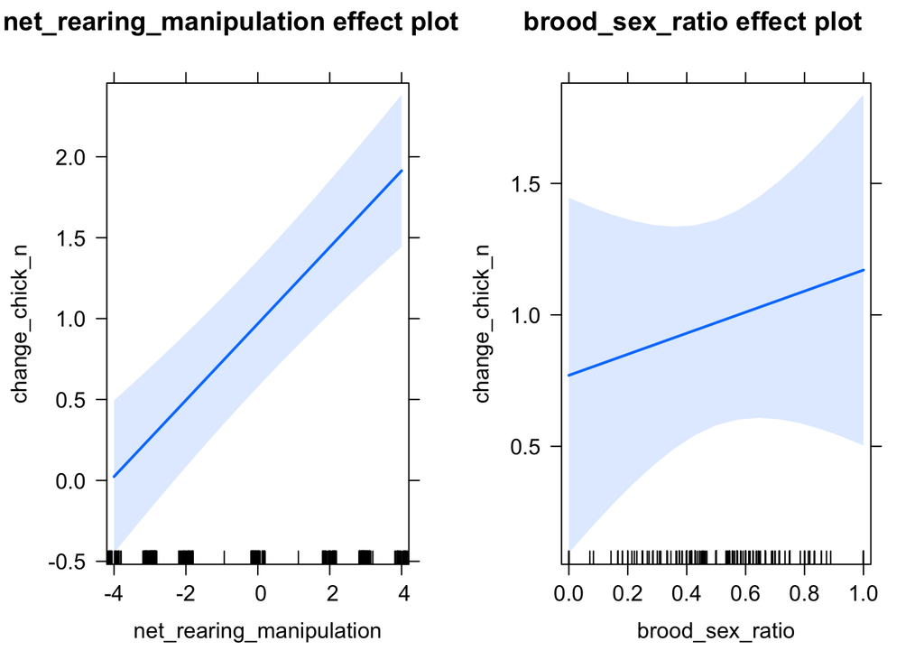

#### Table M

|  | Parameter estimate | 95% credible interval |
| --- | --- | --- |
| fixed |  |  |
| (Intercept) | 0.77 | [0.089, 1.447] |
| net_rearing_manipulation | 0.237 | [0.17, 0.303] |
| brood_sex_ratio | 0.388 | [-0.692, 1.448] |
| random % |  |  |
| rear_nest_OH_l (Intercept) | 0% | [0%, 0%] |
| rear_area (Intercept) | 0% | [0%, 0%] |
| day14_measurer (Intercept) | 2% | [0%, 5%] |
| hatch_year (Intercept) | 1% | [0%, 3%] |
| Residual | 97% | [92%, 100%] |

N = 357 nests, AIC = 1420.79 , Marginal R-squared = 0.12 , Conditional R-squared = NA

## Chick Tarsus Model

### tarsus~net+sex+sex-ratio

This model tests for a change in chick tarsus length at day 14 in response to the net change in brood size following manipulation, the sex of the chick, and the rearing brood sex ratio.

```r
mt0g =  lmer(day_14_tarsus_length ~
    net_rearing_manipulation +
    chick_sex_molec +
    brood_sex_ratio +
    (1|day14_measurer) + (1|rear_area) +
    (1|rear_nest_OH_l) + (1|hatch_year)  +
    (1|rear_nest_breed_ID) +
    (1|hatch_mom_Ring) + (1|genetic_dad),
    data = dtg, REML = reml
    )
```

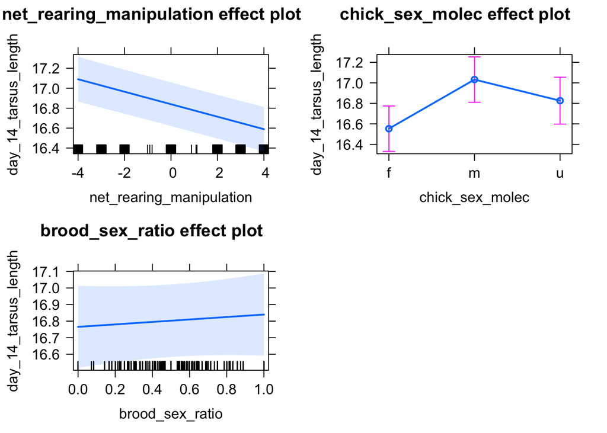

#### Table Ta

|  | Parameter estimate | 95% credible interval |
| --- | --- | --- |
| fixed |  |  |
| (Intercept) | 16.552 | [16.304, 16.798] |
| net_rearing_manipulation | -0.063 | [-0.074, -0.051] |
| chick_sex_molecm | 0.479 | [0.432, 0.526] |
| chick_sex_molecu | 0.274 | [0.183, 0.367] |
| brood_sex_ratio | 0.078 | [-0.155, 0.306] |
| random % |  |  |
| rear_nest_breed_ID (Intercept) | 13% | [13%, 11%] |
| genetic_dad (Intercept) | 10% | [10%, 8%] |
| hatch_mom_Ring (Intercept) | 12% | [12%, 11%] |
| rear_nest_OH_l (Intercept) | 0% | [0%, 0%] |
| rear_area (Intercept) | 1% | [0%, 1%] |
| day14_measurer (Intercept) | 6% | [1%, 20%] |
| hatch_year (Intercept) | 2% | [1%, 4%] |
| Residual | 56% | [45%, 63%] |

N = 2550 nests, AIC = 3993.48 , Marginal R-squared = 0.16 , Conditional R-squared = 0.53

### tarsus~d14+sex+sex-ratio

This model tests for a change in chick tarsus length at day 14 in response to the size of the brood at day 14, the sex of the chick, and the rearing brood sex ratio.

```r
mt14g =  lmer(day_14_tarsus_length ~
    d14_rear_nest_brood_size +
    chick_sex_molec +
    brood_sex_ratio +
    (1|day14_measurer) + (1|rear_area) +
    (1|rear_nest_OH_l) + (1|hatch_year)  +
    (1|rear_nest_breed_ID) + (1|hatch_mom_Ring) + (1|genetic_dad),
    data = dtg, REML = reml
    )
```

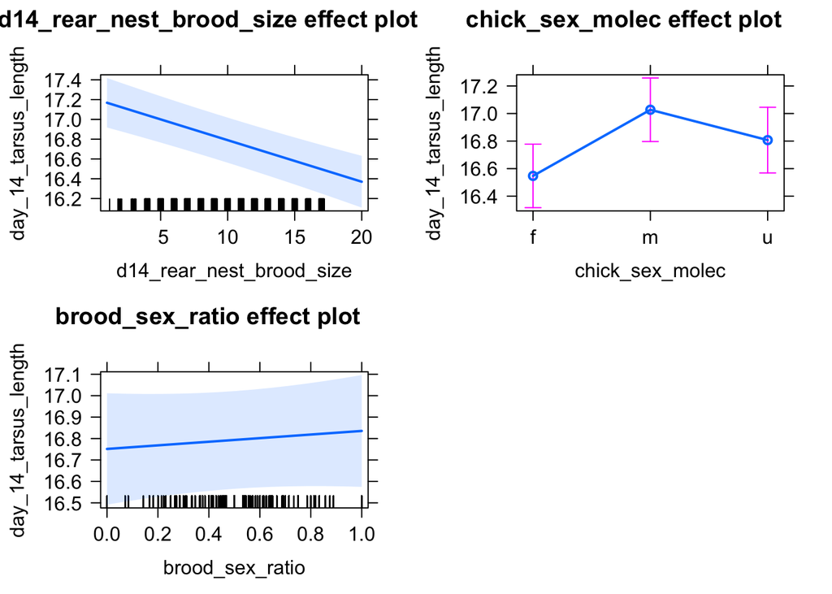

#### Table Tb

|  | Parameter estimate | 95% credible interval |
| --- | --- | --- |
| fixed |  |  |
| (Intercept) | 16.921 | [16.63, 17.203] |
| d14_rear_nest_brood_size | -0.042 | [-0.054, -0.03] |
| chick_sex_molecm | 0.48 | [0.434, 0.526] |
| chick_sex_molecu | 0.259 | [0.164, 0.356] |
| brood_sex_ratio | 0.084 | [-0.169, 0.336] |
| random % |  |  |
| rear_nest_breed_ID (Intercept) | 18% | [18%, 15%] |
| genetic_dad (Intercept) | 10% | [10%, 9%] |
| hatch_mom_Ring (Intercept) | 10% | [10%, 8%] |
| rear_nest_OH_l (Intercept) | 0% | [0%, 0%] |
| rear_area (Intercept) | 2% | [1%, 3%] |
| day14_measurer (Intercept) | 6% | [1%, 21%] |
| hatch_year (Intercept) | 2% | [0%, 3%] |
| Residual | 53% | [41%, 60%] |

N = 2550 nests, AIC = 4052.53 , Marginal R-squared = 0.13 , Conditional R-squared = 0.55

This model tests for a change in chick tarsus length at day 14 in response to sex-specific net change in brood size following manipulation and the rearing brood sex ratio.

```r
mt0gs =  lmer(day_14_tarsus_length ~
    net_rearing_manipulation*chick_sex_molec +
    brood_sex_ratio +
    (1|day14_measurer) + (1|rear_area) +
    (1|rear_nest_OH_l) + (1|hatch_year)  +
    (1|rear_nest_breed_ID)+
    (1|hatch_mom_Ring) + (1|genetic_dad),
    data = dtg, REML = reml
    )
```

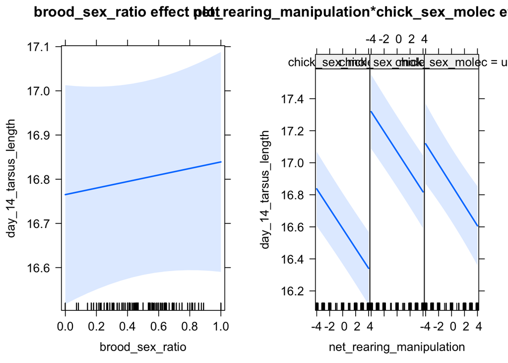

#### Table Tc

|  | Parameter estimate | 95% credible interval |
| --- | --- | --- |
| fixed |  |  |
| (Intercept) | 16.555 | [16.303, 16.791] |
| net_rearing_manipulation | -0.062 | [-0.077, -0.047] |
| chick_sex_molecm | 0.48 | [0.431, 0.527] |
| chick_sex_molecu | 0.275 | [0.178, 0.368] |
| brood_sex_ratio | 0.074 | [-0.156, 0.306] |
| net_rearing_manipulation:chick_sex_molecm | -0.001 | [-0.017, 0.016] |
| net_rearing_manipulation:chick_sex_molecu | -0.002 | [-0.029, 0.025] |
| random % |  |  |
| rear_nest_breed_ID (Intercept) | 13% | [13%, 11%] |
| genetic_dad (Intercept) | 10% | [10%, 8%] |
| hatch_mom_Ring (Intercept) | 12% | [12%, 11%] |
| rear_nest_OH_l (Intercept) | 0% | [0%, 0%] |
| rear_area (Intercept) | 1% | [0%, 1%] |
| day14_measurer (Intercept) | 6% | [1%, 20%] |
| hatch_year (Intercept) | 2% | [1%, 4%] |
| Residual | 56% | [44%, 63%] |

N = 2550 nests, AIC = 3997.45 , Marginal R-squared = 0.16 , Conditional R-squared = 0.53

## Chick Weight Model

### weight~net+sex+sex-ratio

This model tests for a change in chick body weight at day 14 in response to the net change in brood size following manipulation, the sex of the chick, and the rearing brood sex ratio.

```r
mw0g =  lmer(day_14_weight ~
  net_rearing_manipulation +
  chick_sex_molec +
  brood_sex_ratio +
  (1|day14_measurer) + (1|rear_area) +
  (1|rear_nest_OH_l) + (1|hatch_year)  +
  (1|rear_nest_breed_ID) +
  (1|hatch_mom_Ring) + (1|genetic_dad),
  data = dwg, REML = reml
  )
```

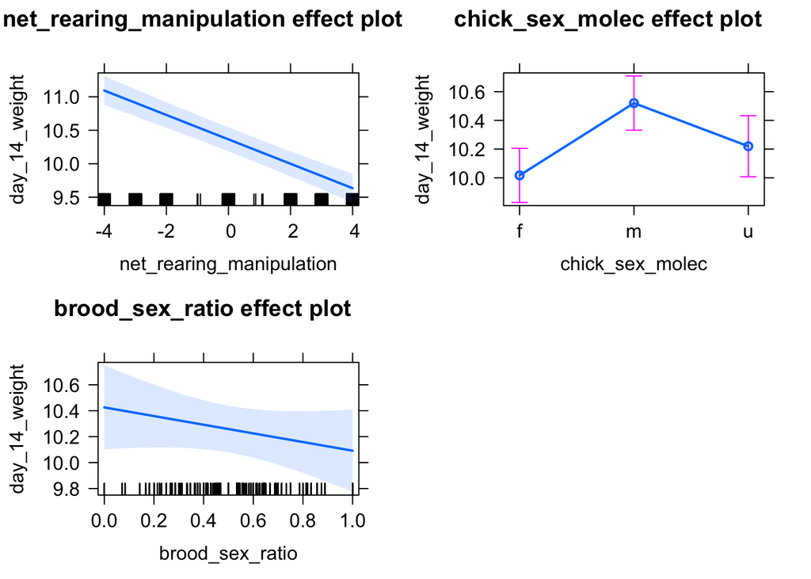

#### Table Wa

|  | Parameter estimate | 95% credible interval |
| --- | --- | --- |
| fixed |  |  |
| (Intercept) | 10.293 | [9.978, 10.615] |
| net_rearing_manipulation | -0.182 | [-0.212, -0.152] |
| chick_sex_molecm | 0.504 | [0.436, 0.572] |
| chick_sex_molecu | 0.2 | [0.043, 0.36] |
| brood_sex_ratio | -0.335 | [-0.874, 0.204] |
| random % |  |  |
| rear_nest_breed_ID (Intercept) | 55% | [54%, 54%] |
| genetic_dad (Intercept) | 4% | [3%, 4%] |
| hatch_mom_Ring (Intercept) | 4% | [4%, 4%] |
| rear_nest_OH_l (Intercept) | 0% | [0%, 1%] |
| rear_area (Intercept) | 2% | [1%, 4%] |
| day14_measurer (Intercept) | 0% | [0%, 0%] |
| hatch_year (Intercept) | 0% | [0%, 2%] |
| Residual | 35% | [32%, 37%] |

### weight~d14size+sex+sex-ratio

This model tests for a change in chick body weight at day 14 in response to the size of the brood at day 14, the sex of the chick, and the rearing brood sex ratio.

```r
mw14g =  lmer(day_14_weight ~
  d14_rear_nest_brood_size +
  chick_sex_molec +
  brood_sex_ratio +
  (1|day14_measurer) + (1|rear_area) +
  (1|rear_nest_OH_l) + (1|hatch_year)  +
  (1|rear_nest_breed_ID) + (1|hatch_mom_Ring) + (1|genetic_dad),
  data = dwg, REML = reml
  )
```

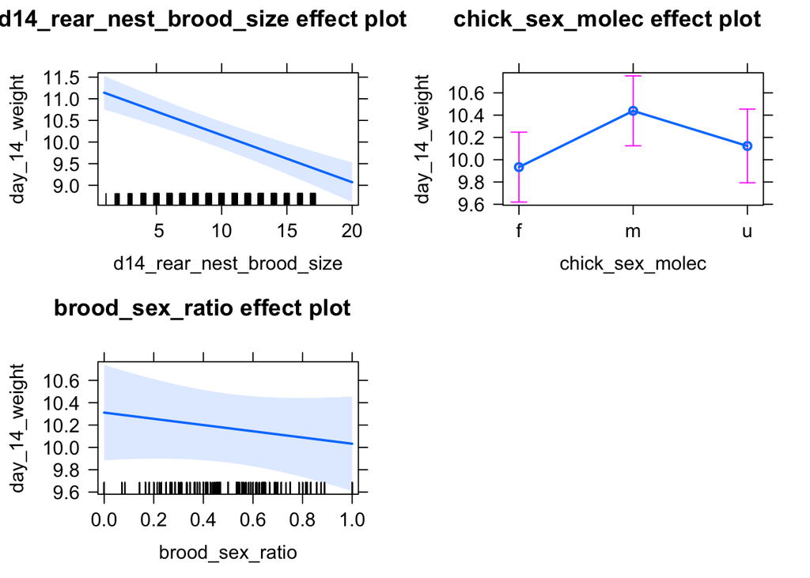

#### Table Wb

|  | Parameter estimate | 95% credible interval |
| --- | --- | --- |
| fixed |  |  |
| (Intercept) | 11.146 | [10.632, 11.658] |
| d14_rear_nest_brood_size | -0.109 | [-0.139, -0.078] |
| chick_sex_molecm | 0.505 | [0.436, 0.571] |
| chick_sex_molecu | 0.191 | [0.012, 0.362] |
| brood_sex_ratio | -0.279 | [-0.859, 0.322] |
| random % |  |  |
| rear_nest_breed_ID (Intercept) | 56% | [58%, 53%] |
| genetic_dad (Intercept) | 3% | [3%, 3%] |
| hatch_mom_Ring (Intercept) | 3% | [3%, 3%] |
| rear_nest_OH_l (Intercept) | 6% | [4%, 8%] |
| rear_area (Intercept) | 3% | [1%, 5%] |
| day14_measurer (Intercept) | 0% | [0%, 0%] |
| hatch_year (Intercept) | 2% | [0%, 4%] |
| Residual | 28% | [24%, 31%] |

N = 2550 nests, AIC = 6190.05 , Marginal R-squared = 0.28 , Conditional R-squared = NA

### weight~netxsex+sex-ratio

This model tests for a change in chick body weight at day 14 in response to a sex-specific net change in brood size following manipulation, the sex of the chick, and the rearing brood sex ratio.

```r
mw0gs =  lmer(day_14_weight ~
  net_rearing_manipulation*chick_sex_molec +
  brood_sex_ratio +
  (1|day14_measurer) + (1|rear_area) +
  (1|rear_nest_OH_l) + (1|hatch_year)  +
  (1|rear_nest_breed_ID)+
  (1|hatch_mom_Ring) + (1|genetic_dad),
  data = dwg, REML = reml
  )
```

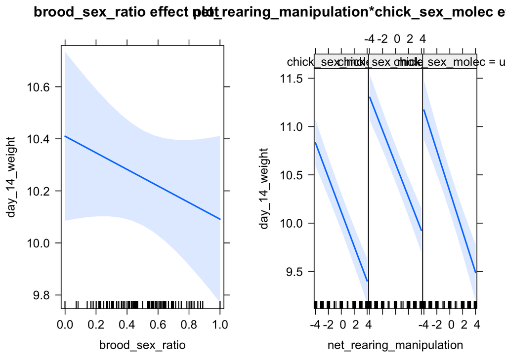

#### Table Wc

|  | Parameter estimate | 95% credible interval |
| --- | --- | --- |
| fixed |  |  |
| (Intercept) | 10.283 | [9.947, 10.606] |
| net_rearing_manipulation | -0.179 | [-0.212, -0.145] |
| chick_sex_molecm | 0.497 | [0.431, 0.566] |
| chick_sex_molecu | 0.213 | [0.05, 0.378] |
| brood_sex_ratio | -0.32 | [-0.843, 0.228] |
| net_rearing_manipulation:chick_sex_molecm | 0.006 | [-0.017, 0.03] |
| net_rearing_manipulation:chick_sex_molecu | -0.031 | [-0.087, 0.025] |
| random % |  |  |
| rear_nest_breed_ID (Intercept) | 55% | [54%, 54%] |
| genetic_dad (Intercept) | 3% | [3%, 4%] |
| hatch_mom_Ring (Intercept) | 4% | [4%, 5%] |
| rear_nest_OH_l (Intercept) | 1% | [0%, 1%] |
| rear_area (Intercept) | 2% | [1%, 4%] |
| day14_measurer (Intercept) | 0% | [0%, 0%] |
| hatch_year (Intercept) | 1% | [0%, 2%] |
| Residual | 35% | [32%, 37%] |

N = 2550 nests, AIC = 6108.78 , Marginal R-squared = 0.2 , Conditional R-squared = 0.69

## Chick Body Mass Index Model

### BMI~net+sex+sex-ratio

This model tests for a change in chick body mass index at day 14 in response to the net change in brood size following manipulation, the sex of the chick, and the rearing brood sex ratio.

```r
mb0g =  lmer(body_mass_index ~
    net_rearing_manipulation +
    chick_sex_molec +
    brood_sex_ratio +
    (1|day14_measurer) + (1|rear_area) +
    (1|rear_nest_OH_l) + (1|hatch_year)  +
    (1|rear_nest_breed_ID) +
    (1|hatch_mom_Ring) + (1|genetic_dad),
    data = dmg, REML = reml
    )
```

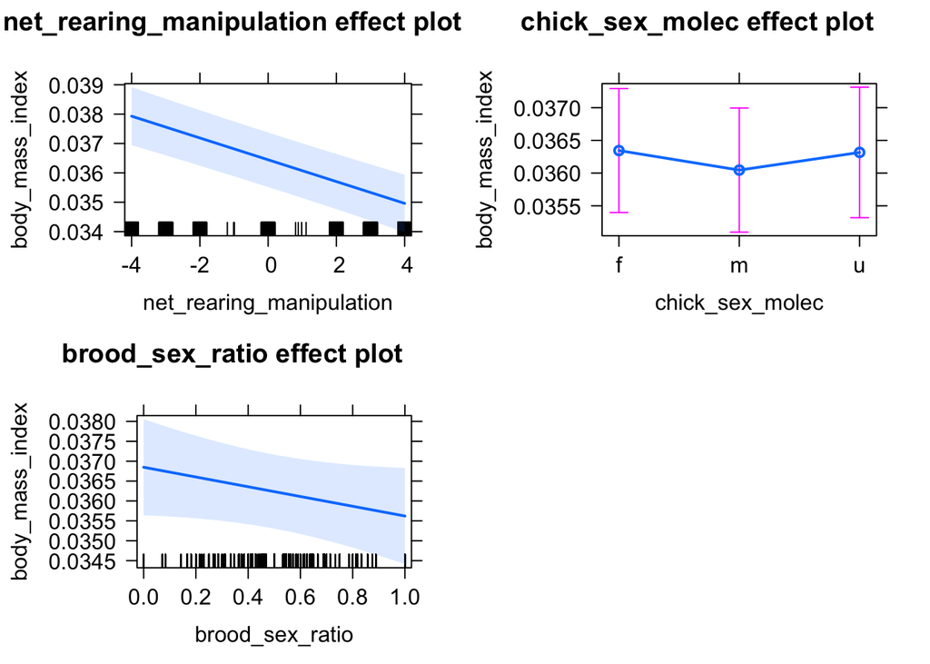

#### Table Ba

|  | Parameter estimate | 95% credible interval |
| --- | --- | --- |
| fixed |  |  |
| (Intercept) | 0.037 | [0.036, 0.038] |
| net_rearing_manipulation | 0 | [0, 0] |
| chick_sex_molecm | 0 | [-0.001, 0] |
| chick_sex_molecu | 0 | [-0.001, 0] |
| brood_sex_ratio | -0.001 | [-0.003, 0] |
| random % |  |  |
| rear_nest_breed_ID (Intercept) | 34% | [35%, 32%] |
| genetic_dad (Intercept) | 3% | [3%, 3%] |
| hatch_mom_Ring (Intercept) | 10% | [10%, 10%] |
| rear_nest_OH_l (Intercept) | 8% | [6%, 10%] |
| rear_area (Intercept) | 0% | [0%, 1%] |
| day14_measurer (Intercept) | 2% | [0%, 5%] |
| hatch_year (Intercept) | 1% | [0%, 3%] |
| Residual | 41% | [36%, 46%] |

N = 2550 nests, AIC = -22914.27 , Marginal R-squared = 0.08 , Conditional R-squared = 0.6

### BMI~d14+sex+sex-ratio

This model tests for a change in chick body mass index at day 14 in response to the size of the brood at day 14, the sex of the chick, and the rearing brood sex ratio.

```r
mb14g =  lmer(body_mass_index ~
    d14_rear_nest_brood_size +
    chick_sex_molec +
    brood_sex_ratio +
    (1|day14_measurer) + (1|rear_area) +
    (1|rear_nest_OH_l) + (1|hatch_year)  +
    (1|rear_nest_breed_ID)+
    (1|hatch_mom_Ring) + (1|genetic_dad),
    data = dmg, REML = reml
    )
```

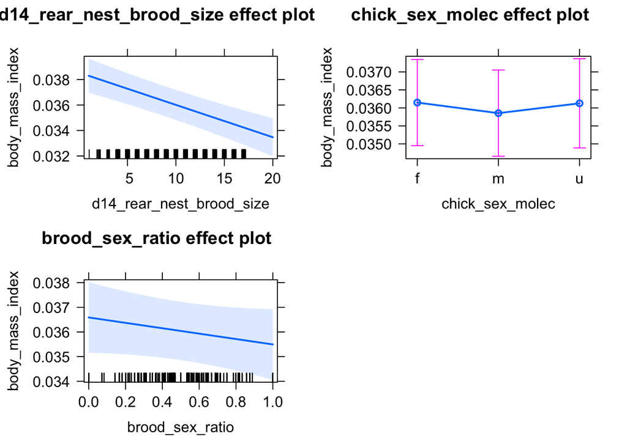

#### Table Bb

|  | Parameter estimate | 95% credible interval |
| --- | --- | --- |
| fixed |  |  |
| (Intercept) | 0.039 | [0.038, 0.041] |
| d14_rear_nest_brood_size | 0 | [0, 0] |
| chick_sex_molecm | 0 | [-0.001, 0] |
| chick_sex_molecu | 0 | [-0.001, 0.001] |
| brood_sex_ratio | -0.001 | [-0.003, 0.001] |
| random % |  |  |
| rear_nest_breed_ID (Intercept) | 35% | [37%, 32%] |
| genetic_dad (Intercept) | 2% | [3%, 2%] |
| hatch_mom_Ring (Intercept) | 8% | [8%, 8%] |
| rear_nest_OH_l (Intercept) | 13% | [9%, 16%] |
| rear_area (Intercept) | 1% | [0%, 1%] |
| day14_measurer (Intercept) | 2% | [0%, 4%] |
| hatch_year (Intercept) | 3% | [1%, 5%] |
| Residual | 36% | [31%, 42%] |

N = 2550 nests, AIC = -22874.68 , Marginal R-squared = 0.05 , Conditional R-squared = 0.63

### BMI~netxsex+sex-ratio

This model tests for a change in chick body mass index at day 14 in response to a sex-specific net change in brood size following manipulation, the sex of the chick, and the rearing brood sex ratio.

```r
mb0gs =  lmer(body_mass_index ~
    net_rearing_manipulation*chick_sex_molec +
    brood_sex_ratio +
    (1|day14_measurer) + (1|rear_area) +
    (1|rear_nest_OH_l) + (1|hatch_year)  +
    (1|rear_nest_breed_ID)+
    (1|hatch_mom_Ring) + (1|genetic_dad),
    data = dmg, REML = reml
    )
```

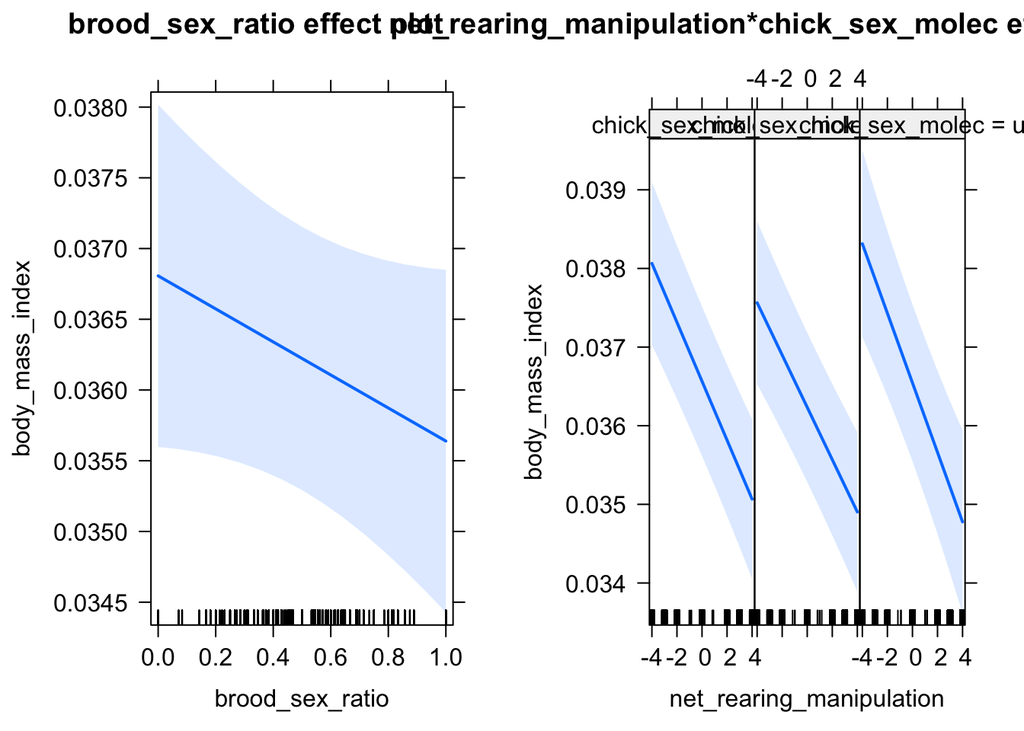

#### Table Bc

|  | Parameter estimate | 95% credible interval |
| --- | --- | --- |
| fixed |  |  |
| (Intercept) | 0.037 | [0.036, 0.038] |
| net_rearing_manipulation | 0 | [0, 0] |
| chick_sex_molecm | 0 | [-0.001, 0] |
| chick_sex_molecu | 0 | [-0.001, 0.001] |
| brood_sex_ratio | -0.001 | [-0.003, 0] |
| net_rearing_manipulation:chick_sex_molecm | 0 | [0, 0] |
| net_rearing_manipulation:chick_sex_molecu | 0 | [0, 0] |
| random % |  |  |
| rear_nest_breed_ID (Intercept) | 34% | [35%, 32%] |
| genetic_dad (Intercept) | 3% | [3%, 3%] |
| hatch_mom_Ring (Intercept) | 10% | [10%, 10%] |
| rear_nest_OH_l (Intercept) | 8% | [6%, 11%] |
| rear_area (Intercept) | 0% | [0%, 1%] |
| day14_measurer (Intercept) | 2% | [0%, 5%] |
| hatch_year (Intercept) | 1% | [0%, 3%] |
| Residual | 41% | [36%, 46%] |

N = 2550 nests, AIC = -22912.43 , Marginal R-squared = 0.08 , Conditional R-squared = 0.6

Note that males tend to have larger tarsus and are heavier (regardless of the treatment), but their body mass index is similar to the one of females.